# Chapter 12: Cash Flow Estimation

FINA 3000 · Business Finance I · Class 23

Dr. Justin Mohr

November 10, 2026

## Forecasting Project Cash Flows

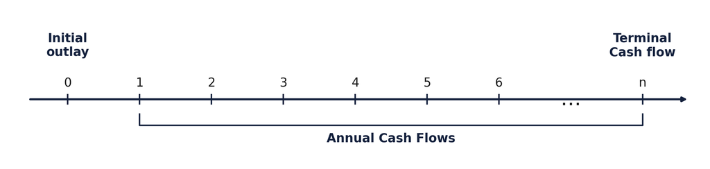

## Estimating CFs: Initial Outlay

Initial Outlay: What is the cash flow at “time 0?”

$$\text{Project Free Cash Flows} = EBIT \left( 1 - T \right) + DEP - \left( CAPEX + \Delta NOWC \right)$$

$$= \left( Rev - Costs - Dep \right) \left( 1 - T \right) + DEP - CAPEX - \Delta NOWC$$

**What we are actually doing**

- No Revenue or costs typically at time 0
- Only the Depreciation, CAPEX, and NOWC

$$\left( 0 - 0 - Dep \right) \left( 1 - T \right) + Dep - CAPEX - \Delta NOWC$$

$$-Dep + T \ast Dep + Dep - CAPEX - \Delta NOWC$$

$$T \ast Dep - CAPEX - \Delta NOWC = -\left( CAPEX - t \ast Dep \right) - \Delta NOWC$$

**Alternative Steps (Book)**

- Find the CAPEX* at time 0
  - Cost - (T × Depreciation)
- Then find any change in ΔNOWC
- The sum of these is the FCF at time zero or the initial capital outlay

## Estimating Incremental CFs

$$\text{Project Free Cash Flows} = EBIT \left( 1 - T \right) + DEP - \left( CAPEX + \Delta NOWC \right)$$

$$= \left( Rev - Costs - Dep \right) \left( 1 - T \right) + DEP - CAPEX - \Delta NOWC$$

- For each year we need to estimate our revenue and costs as well as any depreciation expense
- For most of our problems there is 100% depreciation immediately

## Estimating the Terminal Cash Flow

- Salvage value
  - Book value is the initial price for the asset minus its total accumulated depreciation
  - Tax could be a credit

$$AT_{salvage} = \text{Salvage Value} - T \left( \text{Salvage Value} - \text{Book Value} \right)$$

- Recovery of any net operating working capital
  - Spare parts

## Estimating the Terminal Cash Flow

$$\text{Project Free Cash Flows} = EBIT \left( 1 - T \right) + DEP - \left( CAPEX + \Delta NOWC \right)$$

$$= \left( Rev - Costs - Dep \right) \left( 1 - T \right) + DEP - CAPEX - \Delta NOWC$$

- Salvage value

$$AT_{salvage} = \text{Salvage Value} - T \left( \text{Salvage Value} - \text{Book Value} \right)$$

- Assume that CAPEX decreases by this amount
- Positive AT salvage value increases FCF
- Negative AT salvage value decreases FCF
- Recovery of any net operating working capital
  - Spare parts
  - ΔNOWC

## Issues with Estimating Cash Flows

- Sunk costs=exclude. Ask yourself if rejecting the project affects this cost.
- Financing costs, such as interest expense=EXCLUDE. Already included in WACC.
- Opportunity Costs=INCLUDE. Generally revenues forgone from using land or building for another purpose other than the project
- Externalities=effects of a project on cash flows in other part of the firm. Can be positive or negative and should be INCLUDED as part of the project’s incremental cash flows.
- Cannibalization=INCLUDE. A negative externality, occurs when the introduction of a new product diminishes the sales of existing products.

## Investing in Expanding Gas Pumps

[figure not shown]

- 4 year project life
- New equipment eligible for 100% bonus/upfront depreciation
- New equipment costs $280,000
- Tax rate=25%
- WACC=10%
- New sales: 100,000 units/year @ $2/unit
- Variable cost: 60% of sales
- Salvage value (SV): $25,000, Book Value (BV)=$0 because fully depreciated at time of purchase
- Inventories increase $25,000
- Accounts payable increase $5,000

## Book Method: Initial Outlay

**CAPEX***

- Acquisition Cost=$280,000
- Tax rate=25%
- 100% bonus (immediate) depreciation

**ΔNOWC**

- Δ in inventories of $25,000
- Funded partly by an Δ in A/P of $5,000

## FCF Method: Initial Outlay

**Numbers**

- Acquisition Cost=$280,000, 100% bonus (immediate) depreciation
- Tax rate=25%
- ΔNOWC
  - Δ in inventories of $25,000, Funded partly by an Δ in A/P of $5,000

$$\text{Project Free Cash Flows} = EBIT \left( 1 - T \right) + DEP - \left( CAPEX + \Delta NOWC \right)$$

$$= \left( Rev - Costs - Dep \right) \left( 1 - T \right) + DEP - CAPEX - \Delta NOWC$$

## FCF Method: Intermediate CF

**Numbers**

- New sales: 100,000 units/year @ $2/unit
- Variable cost: 60% of sales
- Same for all 4* years
- Year 4 will have the TV we have to add when we sell equipment

$$\text{Project Free Cash Flows} = EBIT \left( 1 - T \right) + DEP - \left( CAPEX + \Delta NOWC \right)$$

$$= \left( Rev - Costs - Dep \right) \left( 1 - T \right) + DEP - CAPEX - \Delta NOWC$$

## FCF Method: Terminal CF

**Numbers**

- New sales: 100,000 units/year @ $2/unit
- Variable cost: 60% of sales
- Salvage Value: $25,000
- Assume we can fully recover the 20K in NOWC
  - So -20K in ΔNOWC

$$AT_{salvage} = \text{Salvage Value} - T \left( \text{Salvage Value} - \text{Book Value} \right)$$

Under the Book Method you add the Terminal CF to the Operating CF we found in the last slide.

Same Result, but this is more intuitive

$$\text{Project Free Cash Flows} = EBIT \left( 1 - T \right) + DEP - \left( CAPEX + \Delta NOWC \right)$$

## Find NPV, and IRR

- WACC is 10%

The gas-pump project, in thousands

| Time | CF |
| --- | --- |
| 0 | -230 |
| 1 | 60 |
| 2 | 60 |
| 3 | 60 |
| 4 | 98.75 |

## Replacement Projects

- Assume old equipment is sold and new equipment is purchased.
- Also relies on incremental free cash flows
  - Estimate free cash flows associated with new equipment
  - Deduct free cash flows associated with existing equipment
  - Use the difference (incremental free cash flows) to calculate net present value

## Replacement Project CF

- Replacement equipment cost
  - $4,000
  - 100% bonus/upfront depreciation
- Old equipment salvage value today
  - $1,000 ($500 book value)
- New revenue=$5,000 per annum
- New Expenses=$2,500 per annum
- Old revenue=$4,000 per annum
- Old Expenses=$2,650 per annum
- Old depreciation=$100 per annum
- Tax Rate - 25%
- 10% WACC
- 5 year life
- No change in NOWC
- No salvage value for new or equipment if sold in year 5
- Now we are thinking of replacing our existing gas pumps
- Need to account for selling old equipment
- Only care about the CF that will be different

## Replacements Projects

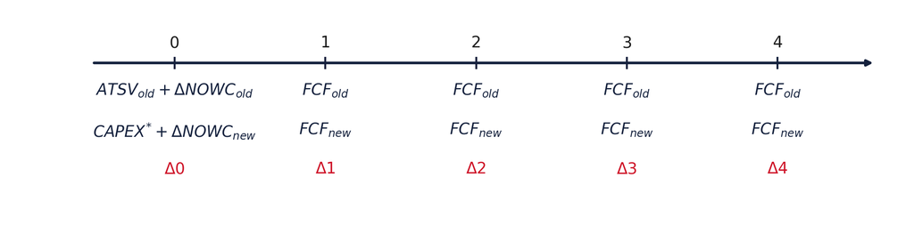

- Find the difference in the CF. The NPV of this will determine if we do the project

## Replacement Project: Initial Outlay

- Replacement equipment cost=$4,000, 100% bonus/upfront depreciation
- Old equipment salvage value today=$1,000 ($500 book value)
- No change in NOWC
- Cash from selling old equipment

$$AT_{salvage} = \text{Salvage Value} - T \left( \text{Salvage Value} - \text{Book Value} \right)$$

- Cash for new

## Replacement Project: Intermediate CF

- New revenue=$5,000 per annum
- New Expenses=$2,500 per annum
- Old revenue=$4,000 per annum
- Old Expenses=$2,650 per annum
- Old depreciation=$100 per annum.

$$\text{OLD Free Cash Flows} = EBIT \left( 1 - T \right) + DEP - \left( CAPEX + \Delta NOWC \right)$$

$$= \left( Rev - Costs - Dep \right) \left( 1 - T \right) + DEP - CAPEX - \Delta NOWC$$

## Replacement Project: Intermediate CF

- New revenue=$5,000 per annum
- New Expenses=$2,500 per annum
- Old revenue=$4,000 per annum
- Old Expenses=$2,650 per annum
- Old depreciation=$100 per annum.

$$\text{New Free Cash Flows} = EBIT \left( 1 - T \right) + DEP - \left( CAPEX + \Delta NOWC \right)$$

$$= \left( Rev - Costs - Dep \right) \left( 1 - T \right) + DEP - CAPEX - \Delta NOWC$$

## Replacement Project: Intermediate CF

- Need the difference between these to go and get the NPV
- So Old FCF is 1038 and new is 1875

## Replacement Project: Decision

What is the NPV with 10%?

The incremental cash flows of replacing

| Time | CF |
| --- | --- |
| 0 | -2125 |
| 1 | 837 |
| 2 | 837 |
| 3 | 837 |
| 4 | 837 |
| 5 | 837 |

## Mutually Exclusive Projects that continue indefinitely

- That’s a lot of words….
- This is the vacuum cleaner problem
  - No longer a grad student, looking at new vacuums
  - Dog, track in dirt, shoes in the house…. Need some performance

Replacement Chain – makes projects equal in length by assuming replication until both projects have the same term

Equal Annual Annuity – takes NPV of projects with different lengths and converts it to an annual number

## Vacuum Choices

- Option A
  - No name brand
  - 90 dollars initial cost
  - Ongoing costs of 20 dollars cause it take me time to vacuum (Time is money)
  - Expected life 2 years
- Option B
  - Miele
  - 400 dollars
  - Expected on going costs of 10 dollars (less time)
  - Expect to last 10 years

[figure not shown]

## Approach One

- Common life
- What happens in year 2?

Each over its own life, which is not a fair comparison

|  | 0 | 1 | 2 | 3 | 4 | 5 | 6 | 7 | 8 | 9 | 10 |
| --- | --- | --- | --- | --- | --- | --- | --- | --- | --- | --- | --- |
| No Name | -90 | -20 | -20 |  |  |  |  |  |  |  |  |
| NPV | ($124.71) |  |  |  |  |  |  |  |  |  |  |
| Miele | -400 | -10 | -10 | -10 | -10 | -10 | -10 | -10 | -10 | -10 | -10 |
| NPV | ($461.45) |  |  |  |  |  |  |  |  |  |  |

The cheap one bought again every two years, so both run ten years

|  | 0 | 1 | 2 | 3 | 4 | 5 | 6 | 7 | 8 | 9 | 10 |
| --- | --- | --- | --- | --- | --- | --- | --- | --- | --- | --- | --- |
| No Name | -90 | -20 | -110 | -20 | -110 | -20 | -110 | -20 | -110 | -20 | -20 |
| NPV | ($441.53) |  |  |  |  |  |  |  |  |  |  |
| Miele | -400 | -10 | -10 | -10 | -10 | -10 | -10 | -10 | -10 | -10 | -10 |
| NPV | ($461.45) |  |  |  |  |  |  |  |  |  |  |

## Approach Two

- Equivalent Annual Annuity
  - We are doing these in perpetuity
  - Find what the equivalent annual payment is for each NPV

No Name

CPT PMT

Miele

CPT PMT

## What vacuum did I end up with?

- The cheap one
- And it died with in a year
- What do I have now?

[figure not shown]

## Project Risk

Market risk is the most relevant risk for capital projects. However, it is very difficult to measure since there is no historical data on a proposed new project

Three ways to look at the risk of one project

| Risk Type | Characteristics |
| --- | --- |
| Stand-alone risk | Measured by σ. Risk of single project company, single company stockholder |
| Corporate risk | Considers firm’s other projects (i.e. diversification) and includes σ and correlation with firm’s other projects |
| Market risk | Most relevant to a diversified investor. Measured by β |

## Risk Measurement and Correlation

Stand-alone risk is the easiest to measure and most often used in capital budgeting decisions.

While not theoretically correct, it does not necessarily lead to poor decisions.

Correlation between all risk types is high since projects tend to be focused on a firm’s core business and its corporate risk is likely to be highly correlated with its market risk.

## Sensitivity Analysis

- Sensitivity analysis measures the effect of changes in a single variable on a project’s NPV.
- To perform a sensitivity analysis, all variables are fixed at their expected values, except for the variable in question which is allowed to fluctuate.
- Resulting changes in NPV are noted.
- Identifies variables that may have the greatest potential impact on profitability and allows management to focus on these variables.
- Shows how sensitive NPV is to changes in one specific variable

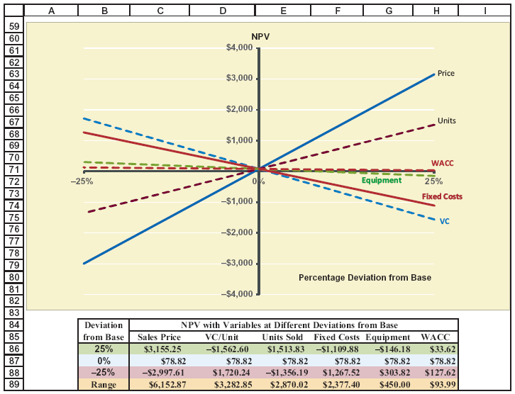

## Scenario Analysis

- Like sensitivity analysis, only different in that:
  - More than one variable can be changed
  - Discrete probabilities applied to different outcomes
  - Looks at project specific volatility and standalone risk
- Can be used to determine whether a company’s weighted average cost of capital (WACC) should be adjusted up or down for a specific project.
- Without potentially adjusting the WACC, riskier projects would have higher NPV’s (since higher risk implies higher return) resulting in a failure to risk adjust or risk weight specific projects

## Scenario Analysis

Probability under different states

Three states of the world for one project

| Case | Probability | NPV | Sales | Price per unit | Variable cost per unit |
| --- | --- | --- | --- | --- | --- |
| Worst | 0.25 | ($43.1) | 10,000 units | $10 | 60% |
| Base | 0.50 | 10.4 | 15,000 units | $12 | 50% |
| Best | 0.25 | 63.9 | 20,000 units | $14 | 40% |

## Scenario Analysis (See Class 12: Chapter 8, Risk and Return)

Three states of the world for one project

| Case | Probability | NPV | Sales | Price per unit | Variable cost per unit |
| --- | --- | --- | --- | --- | --- |
| Worst | 0.25 | ($43.1) | 10,000 units | $10 | 60% |
| Base | 0.50 | 10.4 | 15,000 units | $12 | 50% |
| Best | 0.25 | 63.9 | 20,000 units | $14 | 40% |

Determining Expected NPV, Variance, σ<sub>NPV</sub>, and CV<sub>NPV</sub>

$$E(NPV) = 0.25 \left( -\$43.1 \right) + 0.5 \left( \$10.4 \right) + 0.25 \left( \$63.9 \right) = \$10.4$$

$$\sigma_{NPV}^2 = \left[ 0.25 \left( -\$43.1 - \$10.4 \right)^2 + 0.5 \left( \$10.4 - \$10.4 \right)^2 + 0.25 \left( \$63.9 - \$10.4 \right)^2 \right]$$

$$\sigma_{NPV} = \left( \sigma^2 \right)^{\frac{1}{2}} = \$37.8$$

$$CV_{NPV} = \$37.8 / \$10.4 = 3.6$$

## Unequal Lives

- You are replacing your fully depreciated machine. Model 171-3 has an after-tax cost of $171K, 3yr expected life and after-tax cash flow of $85K per year. Model 356-6 has a after tax cost of $356K, 6yr life and after-tax cash flows of $102.4K per year. Both projects can be repeated and costs of machines are not expected to rise. Assume your WACC is 13%
- Use the replacement chain approach and determine which to buy

## Unequal Lives

- You are replacing your fully depreciated machine. Model 171-3 has an after-tax cost of $171K, 3yr expected life and after-tax cash flow of $85K per year. Model 356-6 has a after tax cost of $356K, 6yr life and after-tax cash flows of $102.4K per year. Both projects can be repeated and costs of machines are not expected to rise. Assume your WACC is 13%
- Use the EAA

CPT PMT

CPT PMT

## NPV Practice

- A project pays $5k per year for 10 years and then $9k per year for the following ten years. The 20 year IRR is 8.52% and the WACC is 8%. What is the NPV?
- First, what are we missing for NPV?
- How can IRR help?
- Use the cash flow register
  - 0 for CF0, 5k for 10 years, 9K for another 10 years.
  - Then use 8.52% for I and get NPV
- Go back and update CF register and use WACC for I.

## Replacement Discussion

- A gas power plant was built 6 years ago at a cost of $120M with a useful life of 10 years. It is being depreciated to zero using 10-year straight-line depreciation. The plant can be sold today for $40M. This plant has no salvage value at the end of its life.
- The nuclear plant would cost $500M to build today. It can be fully depreciated and expensed immediately. The Nuclear Fusion Plant is expected to have a salvage value of $50M at the end of the plant’s 4-year life. The nuclear plant will reduce OPEX by $150M each year increase revenues by $40M each year. The company’s marginal tax rate is 25%, and this project has a WACC of 11%.
- What is the incremental initial cash flow for this replacement analysis?
- What is the year 1 incremental CF for the proposed plant replacement?
- What is the terminal end of project incremental cash flow at the end of year 4 for this replacement analysis?

## Replacement Discussion

- A gas power plant was built 6 years ago at a cost of $120M with a useful life of 10 years. It is being depreciated to zero using 10-year straight-line depreciation. The plant can be sold today for $40M. This plant has no salvage value at the end of its life.
- The nuclear plant would cost $500M to build today. It can be fully depreciated and expensed immediately. The Nuclear Fusion Plant is expected to have a salvage value of $50M at the end of the plant’s 4-year life. The nuclear plant will reduce OPEX by $150M each year increase revenues by $40M each year. The company’s marginal tax rate is 25%, and this project has a WACC of 11%.
- What is the incremental initial cash flow for this replacement analysis?
- What is the capital invested initially?

## Replacement Discussion

- A gas power plant was built 6 years ago at a cost of $120M with a useful life of 10 years. It is being depreciated to zero using 10-year straight-line depreciation. The plant can be sold today for $40M. This plant has no salvage value at the end of its life.
- The nuclear plant would cost $500M to build today. It can be fully depreciated and expensed immediately. The Nuclear Fusion Plant is expected to have a salvage value of $50M at the end of the plant’s 4-year life. The nuclear plant will reduce OPEX by $150M each year increase revenues by $40M each year. The company’s marginal tax rate is 25%, and this project has a WACC of 11%.
- What is the year 1 incremental CF for the proposed plant replacement?

## Replacement Discussion

- A gas power plant was built 6 years ago at a cost of $120M with a useful life of 10 years. It is being depreciated to zero using 10-year straight-line depreciation. The plant can be sold today for $40M. This plant has no salvage value at the end of its life.
- The nuclear plant would cost $500M to build today. It can be fully depreciated and expensed immediately. The Nuclear Fusion Plant is expected to have a salvage value of $50M at the end of the plant’s 4-year life. The nuclear plant will reduce OPEX by $150M each year increase revenues by $40M each year. The company’s marginal tax rate is 25%, and this project has a WACC of 11%.
- What is the terminal end of project incremental cash flow at the end of year 4 for this replacement analysis?
  - ΔFCF will still be the same, but will need to add the after tax ΔSV

## Upcoming Dates

Upcoming class dates and deadlines

| Date | Topic | Due / Notes |
| --- | --- | --- |
| Thu Nov 12 | Review for Test 3 | Review |
| Sun Nov 15 | MindTap Ch 12 | HW DUE |
| Tue Nov 17 | Test 3 | EXAM |
| Thu Nov 19 | Review for Final | Review |

**Office:** 325 Holman Hall · **Office hours:** T TH 10:50A-12:20P · jjmohr1@olemiss.edu